# Generating a buffer

A buffer is a polygon layer that indicates the difference with a specified distance of a set of features.

# Required packages

This example uses the following packages

```r
library(tidyverse)
library(sf)
library(here)
library(leaflet)
```

# Load some sample data

I’ll demonstrate buffers from points, lines, and polygons.

```r
leaflet() %>%
  addProviderTiles(provider = providers$Stamen.TerrainBackground) %>%
  setView(lng = -120.6592, lat = 35.28190, zoom = 12) %>%
  addCircleMarkers(data = stops,
                   radius = 2,
                   stroke = FALSE,
                   fillColor = "darkorange",
                   fillOpacity = 1) %>%
   addPolylines(data = trails,
                color = "brown",
                weight = 1.5,
                opacity = 1) %>%
   addPolygons(data = city,
               fill = NA,
               color = "black",
               opacity = 1,
               weight = 2)
```

[interactive chart not shown]

# Transform the data

To generate accurate buffers, my data need to be stored in a projected coordinate system (with coordinates in units of distance).

I’ll use the California State Plane, zone V (https://spatialreference.org/ref/esri/102645/), which stores coordinates in units of feet.

```r
# Define CA-state-plane
CA_st_plane <- "+proj=lcc +lat_1=34.03333333333333 +lat_2=35.46666666666667 +lat_0=33.5 +lon_0=-118 +x_0=2000000 +y_0=500000.0000000002 +ellps=GRS80 +datum=NAD83 +to_meter=0.3048006096012192 +no_defs"

trails_st_plane <- trails %>%
  st_transform(CA_st_plane)

stops_st_plane <- stops %>%
  st_transform(CA_st_plane)

city_st_plane <- city %>%
  st_transform(CA_st_plane)
```

# Point Buffers

The `st_buffer()` function will generate a buffer around a each feature in your dataset. For a layer of points, this will be a pile of circles, each centered on a stop. The `dist` parameter is the radius of each circle, in the same units as the coordinate system.

The Califonia State Plane system I’m using is in feet, so I need to specify the distance in feet. I’ll use 10560 feet (two miles).

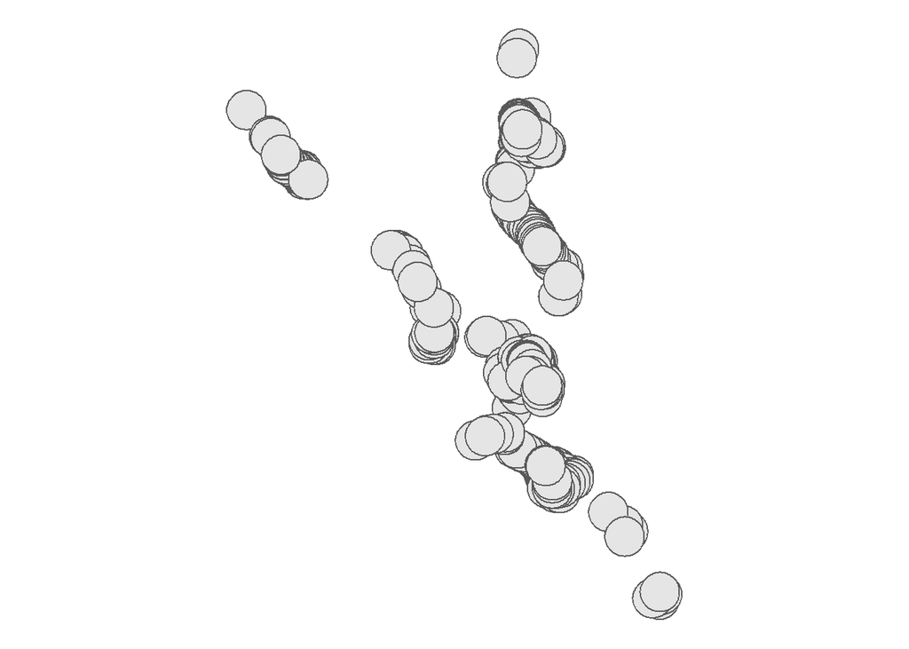

```r
stop_buffers <- stops_st_plane %>%
  st_buffer(dist = 10560)

ggplot() +
  geom_sf(data = stop_buffers) +
  theme_void()
```

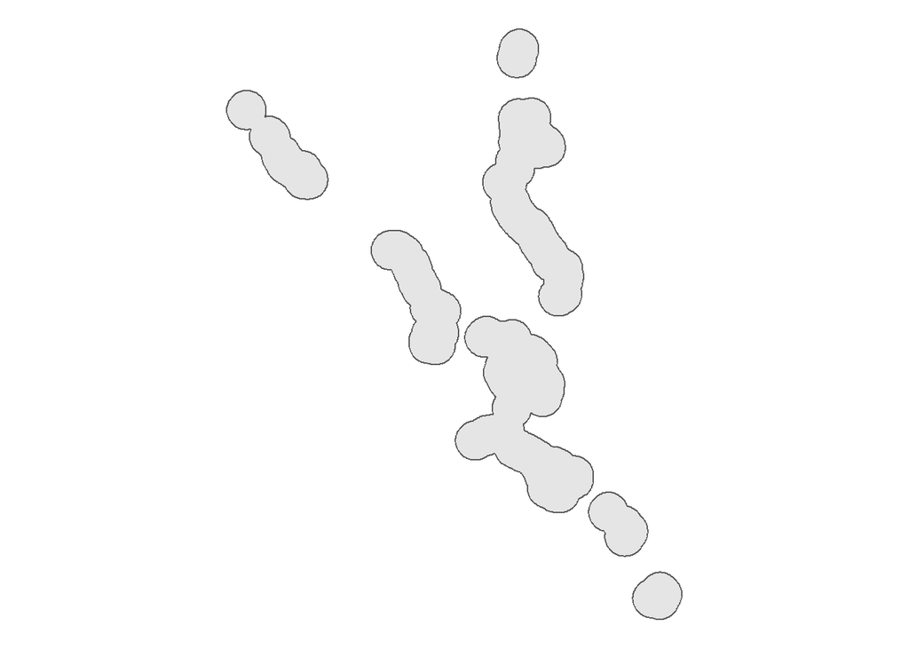

```r
stop_buffer_combined <- stops_st_plane %>%
  st_buffer(dist = 10560) %>%
  st_union()

ggplot() +
  geom_sf(data = stop_buffer_combined) +
  theme_void()
```

# Line buffers

The `st_buffer` function works the same way for lines. Here’s the area within a half mile of a trail.

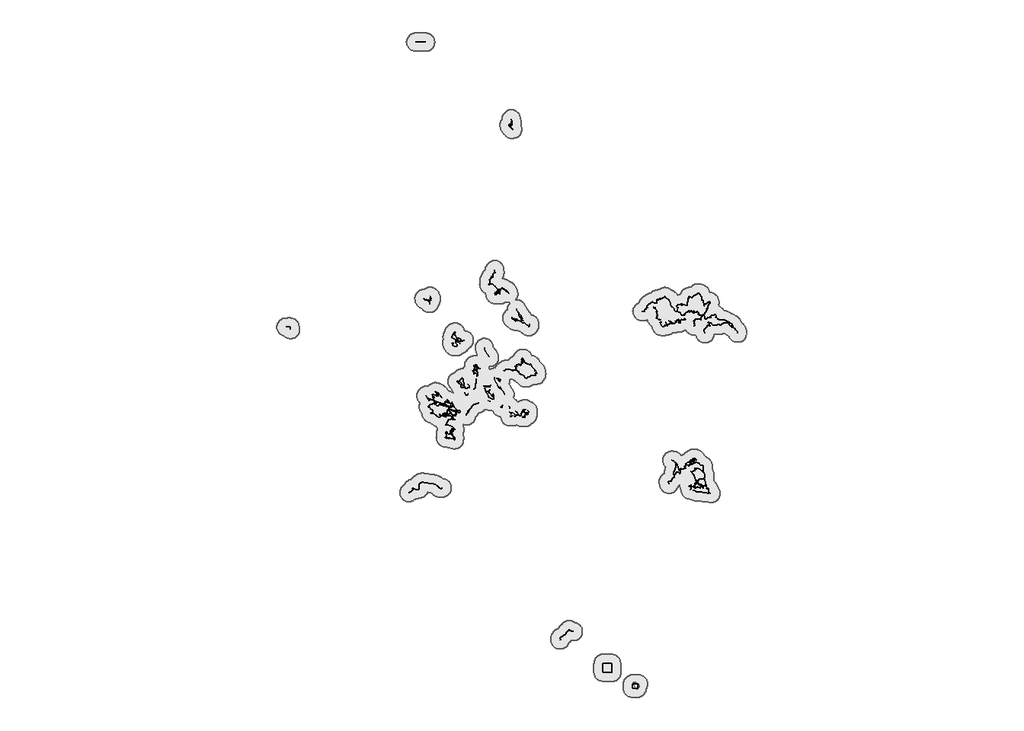

```r
trail_buffer <- trails_st_plane %>%
  st_buffer(dist = 2640) %>%
  st_union()

ggplot() +
  geom_sf(data = trail_buffer) +
  geom_sf(data = trails) +
  theme_void()
```

# Polygon buffers

And you can also create a buffer around a polygon. Here’s the area within a half mile of the San Luis Obispo city limits.

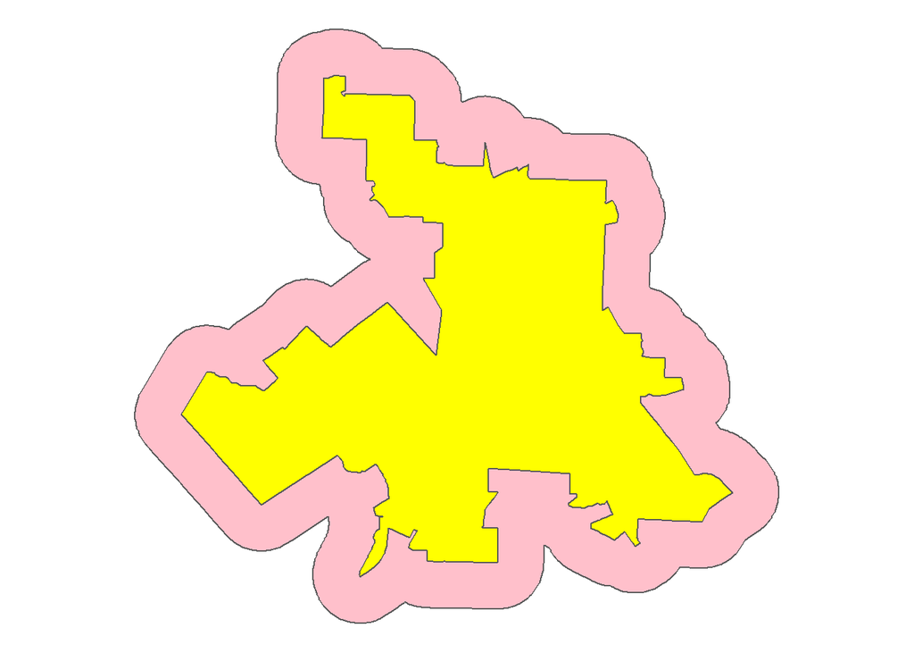

```r
city_buffer <- city_st_plane %>%
  st_buffer(dist = 2640)

ggplot() +
  geom_sf(data = city_buffer,
          fill = "pink") +
  geom_sf(data = city_st_plane,
          fill = "yellow") +
  theme_void()
```